# Miltestone

Gregory Smith

March 20, 2016

# Milestone - Corpus Cleanup & Analysis

## Corpus creation and cleanup

Required Libraries

### Corpus creation

After some initial cleanup of the twitter data(due do some possible file corruption or special characters not common to English), the three files are read into a volatile Corpora using the VCorpus call, part of the tm library.

The three files are comprised of:

en_US.blogs.txt Size - 205,235 kb Entries - 899,288

en_US.news.txt Size - 200,989 kb Entries - 77,259

en_US.twitter.txt Size - 163,735 kb Entries - 2,360,151

## Raw Corpus Info

The size of the corpus in memory is 599.4 Meg. It took 35.45 seconds to read in the corpus.

### Steps to clean data

*Remove Numbers* Transfer to lowercase *Remove Punctuation* Remove profanity *Limit all remaining characters to alpha* Remove white space

Since “stopwords” are a vital part of the English language the will be necessary for the model.

The Twitter file contains several unusual characters. Although these could be cleaned with the rest of the corpus, for timing efficiency they will be cleaned prior to reading into the corpus.

## Determine the sample size

The amount of data contained in the raw corpus is substantially more data than can be efficiently used.

### With an inital sample set at 5%

Unique Words - 108,097

Bi-grams - 1,111,191 2+ occurrences - 257,306 10+ occurrences 36,085

Tri-grams - 2,308,081 2+ occurrences - 235,449 10+ occurrences 16,205

4-grams - 2,765,625 2+ occurrences - 94,605 10+ occurrences 2,233

5-gram - 2,768,124 2+ occurrences - 27,587 10+ occurrences 242

### With the sample set at 7.5%

Unique Words - 137,880

Bi-grams - 1,523,245 2+ occurrences - 365,178 10+ occurrences 53,667

Tri-grams - 3,332,343 2+ occurrences - 365,170 10+ occurrences 27,661

4-grams - 4,107,512 2+ occurrences - 160,973 10+ occurrences 4,429

5-grams - 4,155,420 2+ occurrences - 50,016 10+ occurrences 566

### With the sample set at 10%

unique words - 163,605

Bi-grams - 1,896,807 2+ occurrences - 463,956 10+ occurrences 70,548

Tri-grams - 4,303,158 2+ occurrences - 493,656 10+ occurrences 39,291

4-grams - 5,408,322 2+ occurrences - 229,837 10+ occurrences 7,032

5-grams - 5,513,363 2+ occurrences - 70,548 10+ occurrences 1,005

### With the sample set at 12.5%

Unique words - 186,173

Bi-grams -2,241,504 2+ occurrences - 558,512 10+ occurrences 86,474

Tri-grams -5,231,169 2+ occurrences - 621,953 10+ occurrences 51,361

4-grams * * *

5-grams * * *

with 12.5% size sample NGramTokenizer returned out of memory error while tokenizing 4-gram and 5-gram.

### with the sample set at 15%

Unique words 208,337

Bi-grams * * *

Tri-grams * * *

4-grams * * *

5-grams * * *

With 15% size sample NGramTokenizer returned out of memory error.

## Sample Size Summary

Since additional information is added as the corpus size increases. The model will be based on a 10% sample size corpus. Since the desktop creating the Document-Term-Matrix has 4 Gigs allocated to the heap size, the 10% corpus should allow a sizable DTM to use for the model.

If DTM proves to be too big for efficient use, the occurrence of the n-gram can be used as a variable.

## Word Counts With 10% sample Rates

Blog - 2874194

News - 210692

Twitter - 2278898

## The Twitter Impact

Through the exploration of data, it becomes apparent that certain phrases and terms occur at a much higher probability than would occur in natural language usage. In order to offset the “Twitter Bias”. The weight of the various models will need to be adjusted to more closer match natural language usage.

Examples - The most common 4-gram is

Thanks for the follow

While exploring the break down of a 3 gram

“good night” bi-gram leads to “twitter” 23.4% of occurrences.

The nature of auto response in twitter is influencing the model.

## Adjusting the sample rates for the corpus

To balance the smaller news corpus, the news sample will be weighted with a multiple of 4

To counter the “Twitter Bias”, the twitter sample will be weighted with a multiple of .5

The Blog sample weight will remain the same.

The sample percentage is 10%.

The weight for the blog is 1.

The weight for the news is 4.

the weight for the twitter is 0.5.

# Creation of the Term Document Matrix

```
         Total Number of Words
```

Blog 2874194

News 840846

Twitter 1135336

## Determine Percentage of words covered by cut count

# Corpus Coverage by Frequent Words

The top 10 frequent words.

```r
head(gramsStats.single, 10)
```

```
##         count        Prob grams
## 131725 293631 0.060483550   the
## 4437   157771 0.032498442   and
## 131622  69886 0.014395460  that
## 47356   66684 0.013735896   for
## 149476  61810 0.012731926   you
## 146682  45296 0.009330292  with
## 143642  40999 0.008445175   was
## 132532  37698 0.007765218  this
## 57141   35057 0.007221212  have
## 18099   31429 0.006473899   but
```

Coverage is the percentage of total words in the corpus covered. The sample of the corpus contains about 150,000 unique words The top 10% of most frequently used words cover 92.8% of the words used in the corpus.

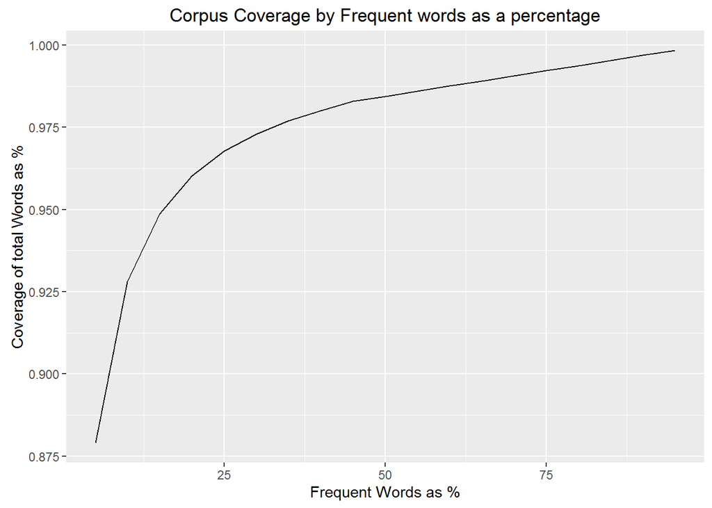

# Bi-gram Coverage by percentage

The top 10 bi-grams are:

```r
head(gramsStats.bi, 10)
```

```
##         count        Prob    grams
## 1069220 27375 0.004570463   of the
## 757134  25001 0.004174105   in the
## 1595635 13234 0.002209516   to the
## 1087299 11879 0.001983289   on the
## 573024  11776 0.001966092  for the
## 1585124 10412 0.001738362    to be
## 144013   8413 0.001404614   at the
## 96616    8266 0.001380071  and the
## 748239   7264 0.001212780     in a
## 1747188  6750 0.001126963 with the
```

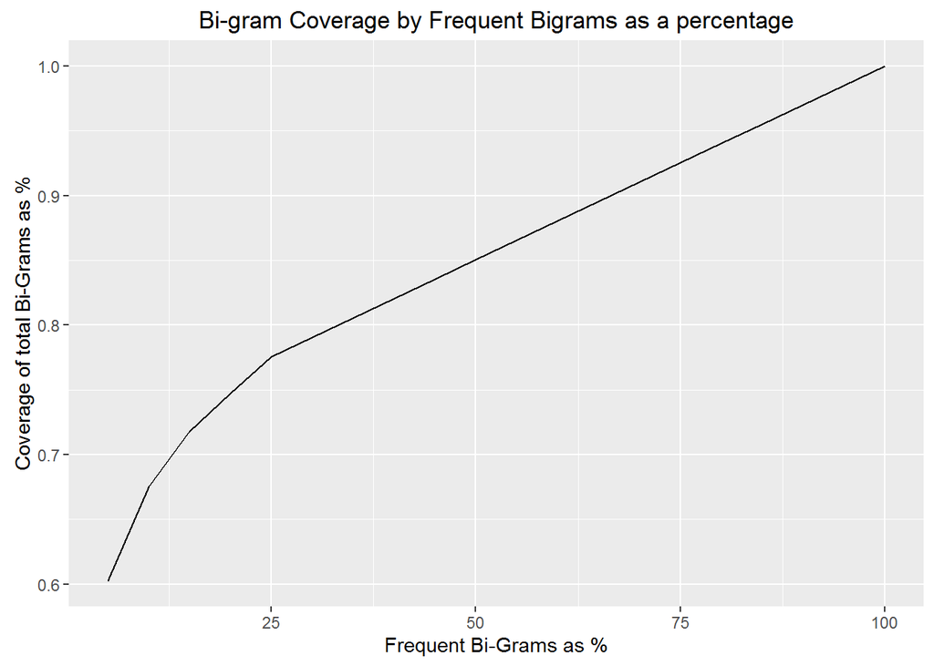

Suggested cut-point at 25% of frequent top bi-grams.

# Tri-gram Coverage by percentage

The top 10 tri-grams are:

```r
head(gramsStats.tri, 10)
```

```
##         count         Prob          grams
## 2412349  2062 0.0003584265     one of the
## 41591    1889 0.0003283548       a lot of
## 3173487  1151 0.0002000722 thanks for the
## 3509417  1091 0.0001896427        to be a
## 1566443  1088 0.0001891213        i don t
## 1325925  1046 0.0001818206    going to be
## 1589011  1004 0.0001745200      i want to
## 3259597   983 0.0001708697     the end of
## 1774715   952 0.0001654811       it was a
## 388665    929 0.0001614831     as well as
```

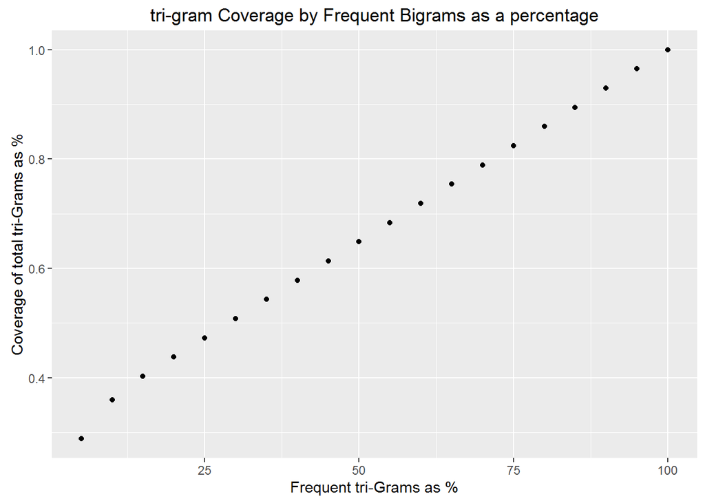

## Modeling the data

The primary concern with the determincation of how many occurances of a given n-gram should be kept and which should be cut. The smaller the cut number the higher the acuracy of the model but also the larger the dataset. Finding the correct balance will be key to the success of the model.

# Prediction algorithm

The prediction model will be based on the a backoff process of looking at the first three words of a 4-gram. If there is a match compare the frequencies of the matches. If there isn’t a match it will fall back to the tri-gram, etc.